# Introduction and R

## About Us

**John Muschelli**

Assistant Scientist, Department of Biostatistics

PhD in Biostatistics

- worked on fMRI, sMRI, and CT for ≈ 7 years

Email: jmusche1@jhu.edu

**Kristin Linn**

Assistant Professor, Department of Biostatistics and Epidemiology Perelman School of Medicine, University of Pennsylvania

PhD in Statistics

- worked on sMRI for 3 years

Email: klinn@mail.med.upenn.edu

## Overall Pipeline

## Imaging Data Used: Multiple Sclerosis

- Multiple sclerosis (MS) is a chronic disease of the central nervous system (brain, spinal chord, optic nerves)
- MS lesions in the brain are areas of active inflammation, demylenation, or permanent tissue damage.
  - lesions are primarily in the white matter
- The full data is available at https://smart-stats-tools.org.

## Imaging Data Used: Multiple Sclerosis

- MRI is well-suited for assessing lesion burden (volume and patterns) because lesions appear as hyperintensities on FLAIR and T2-w images and as hypointensities on T1-w images.
- Using 5 training and 3 test subjects data from the an open MS data set (http://lit.fe.uni-lj.si/tools.php?lang=eng) (Lesjak et al. 2017)

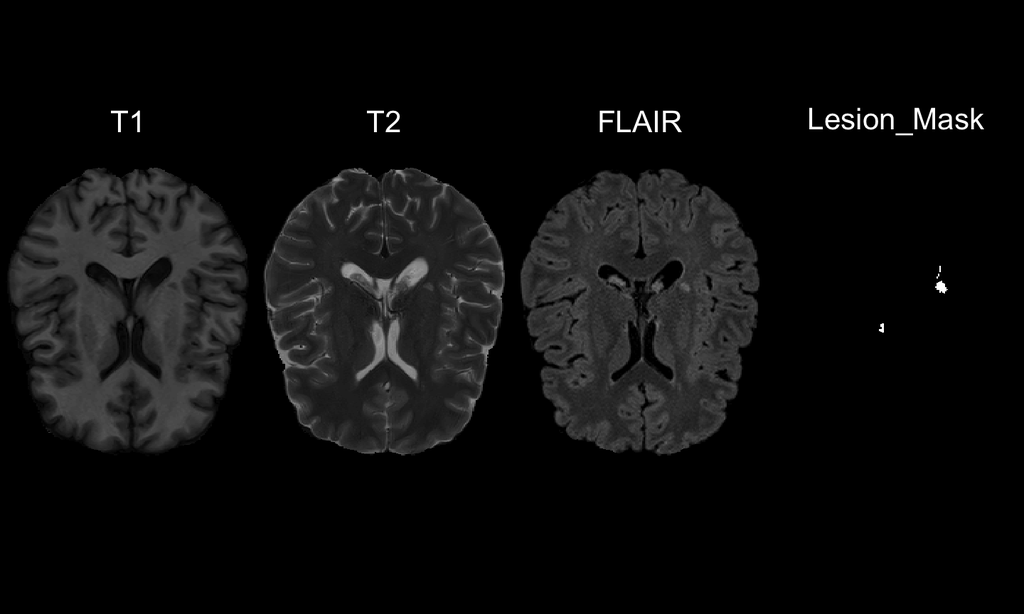

## Formats of Images

There are multiple imaging formats. We will use NIfTI:

- Neuroimaging Informatics Technology Initiative (https://nifti.nimh.nih.gov/nifti-1)
  - essentially a header and data (binary format)
  - will have extension .nii (uncompressed) or .nii.gz (compressed)
  - we will use 3-D images (4-D and 5-D are possible)
- ANALYZE 7.5 was a precursor to NIfTI
  - had a `hdr` file (header) and `img` file (data)

## Course Website/Materials

The Course overview is located at (with slides): http://johnmuschelli.com/ISBI_2017.html

All materials for this course (including source for the slides) is located at:

https://github.com/muschellij2/imaging_in_r

**RStudio Server**

For this course, we will use an RStudio Server because installing all the packages can be a lengthy process. Mostly all the code we show requires a Linux/Mac OSX platform for FSL and other systems:

http://johnmuschelli.com/rstudio_server.html

**Virtual Machine**

If you want to run things locally, we have a Virtual Machine you can download and install: https://neuroconductor.org/neuroc-vm

## Introduction to R

## What is R?

- R is a language and environment for statistical computing and graphics
- R was implemented over the S language, which was developed by Bell laboratories
- R is both open source and open development

(source: http://www.r-project.org/)

## Why R?

- Powerful and flexible
- Free (open source)
- Extensive add-on software (packages)
- Designed for statistical computing
- High level language

**Why not R?**

- Fairly steep learning curve
- Little centralized support, relies on online community and package developers
- Slower, and more memory intensive, than the more traditional programming languages (C, Java, Perl, Python)

## What comes with R

- R revolves around functions
  - Commands that take input, performs computations, and returns results
  - When you download R, it has a “base” set of functions/packages (**base R**)
- Functions are enclosed in packages
  - A package is collection of functions, documentation, data, and tutorials (called vignettes).
  - Written by R users/developers (like us) - **some are bad**
  - You install a package using the `install.packages` command/function:

```r
install.packages("oro.nifti")
```

`install.packages` is a function, `"oro.nifti"` is a character string.

## Neuroconductor

- Most packages are in a repository [Comprehensive R Archive Network (CRAN)](https://cran.r-project.org/)
- Neuroconductor (https://neuroconductor.org/) has packages related to medical imaging

```r
source("https://neuroconductor.org/neurocLite.R")
neuro_install("oro.nifti")
```

## Loading Packages

When you install a package, it’s downloaded to the hard disk. That *doesn’t* mean that you can use the functions from that package just yet.

- You “load”/import a package into memory using the `library` command

For example, to load the `oro.nifti` package:

```r
library(oro.nifti)
```

Now, functions from the `oro.nifti` package can be used.

## RStudio (the software)

RStudio is an Integrated Development Environment (IDE) for R (made by RStudio the company)

- It helps the user effectively and more easily use R.
  - Syntax highlighting, code completion, and smart indentation
  - Easily manage multiple working directories and projects
- Is NOT dropdown statistical tools (such as Stata)
  - See [Rcmdr](https://cran.r-project.org/web/packages/Rcmdr/index.html) or [Radiant](http://vnijs.github.io/radiant/)

## R essentially is a command line with a set of functions loaded

## RStudio/R Console

- Where code is executed (where things happen)
- You can type here for things interactively
- Code is **not saved** on your disk
  - Can act as a calculator
  - Creating variables/objects
  - Applying functions

## RStudio/R Console

[figure not shown]

## Source

- Where files open to
- Have R code and comments in them
  - Static copy of what you did (reproducibility)
  - Try things out interactively, then add to your script
- Can highlight and press (CMD+Enter (Mac) or Ctrl+Enter (Windows)) to run the code
- Code is saved to disk

## Source/Editor

[figure not shown]

## Workspace/Environment

- Tells you what **objects** are in R
- What exists in memory/what is loaded?/what did I read in?

**History**

- Shows previous commands. Good to look at for debugging, but **don’t rely** on it as a script. Make a script!
- Also type the “up” key in the Console to scroll through previous commands

## Workspace/Environment

[figure not shown]

## Other Panes

- **Files** - shows the files on your computer of the directory you are working in
- **Viewer** - can view data or R objects
- **Help** - shows help of R commands
- **Plots** - pretty pictures
- **Packages** - list of R packages that are loaded in memory

## Website

http://johnmuschelli.com/imaging_in_r

## References

Lesjak, Žiga, Alfiia Galimzianova, Aleš Koren, Matej Lukin, Franjo Pernuš, Boštjan Likar, and Žiga Špiclin. 2017. “A Novel Public MR Image Dataset of Multiple Sclerosis Patients with Lesion Segmentations Based on Multi-Rater Consensus.” *Neuroinformatics*, 1–13.